# TippingPoint

Shengjie Zhang & Xikun Han

2022-02-26

A manual to show the R package `TippingPoint`.

## Introduction

The `TippingPoint` package aims to handle missing outcome data by listing out all the possible combinations of the values of missing data in two treatment arms, calculating corresponding estimated treatment effects and p-values, finding the margin(the so-called Tipping Point) that would change the result of the study and drawing a colored heat-map to visualize them. In addition, the package provides a visualized method to compare various imputation methods by adding the rectangles or convex hulls on the basic plot. Several examples are used to explain the idea.

```r
# If you haven't install the package, you can download it from cran

# install.packages("TipingPoint")

library(TippingPoint)

# Load the dataset

data(tippingdata)

# Show the first 6 rows of the data

head(tippingdata)
```

```
##   continuous binary educ female treat
## 1   119.7820      1   12      0     1
## 2   117.7729      0   16      0     1
## 3   124.7833      0   12      1     1
## 4   123.3546      0   12      1     1
## 5   124.6611      0   12      1     1
## 6         NA      1   15      0     1
```

## Basic plot

```
##
## Group Information:
##
## Groups                       Treatment   Control
## Size                          150         120
## Number of nonrespondents      13          27
## % of nonrespondents           0.08666667      0.225
## Observed proportion           0.5328467   0.5376344
```

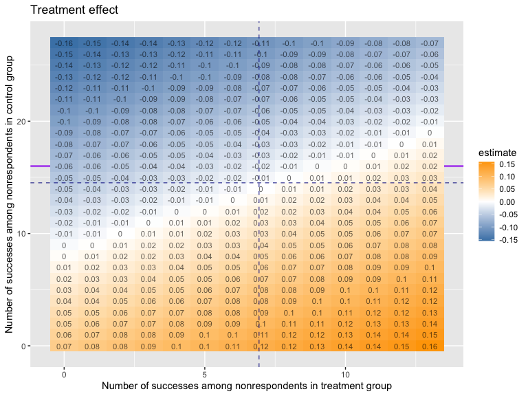

```r
## for binary outcome


# Using `estimate`
TippingPoint(outcome=tippingdata$binary,
             treat= tippingdata$treat,group.infor=TRUE,
             plot.type = "estimate",ind.values = TRUE,
             impValuesT  = NA,  impValuesC = NA,
             summary.type = "density", alpha = 0.95, S=1.5, n.grid = 100,
             HistMeanT = c(0.38,0.4), HistMeanC =  c(0.2,0.55))
```

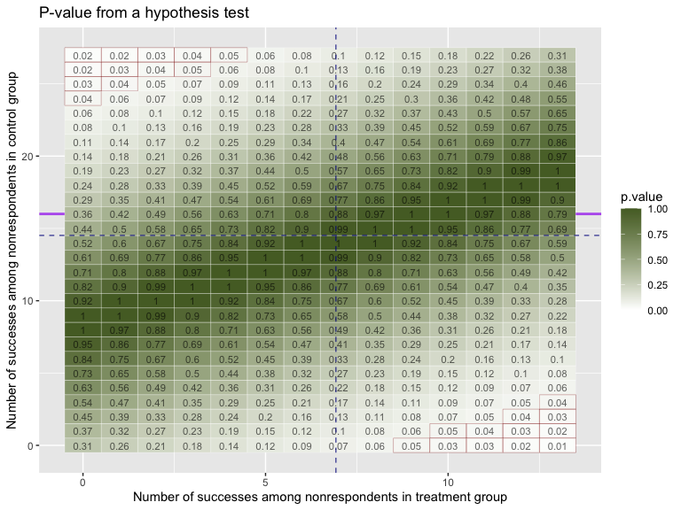

```r
# Using `p.value` with formula class
TippingPoint(binary~treat, data=tippingdata,
             plot.type = "p.value",ind.values = TRUE,
             impValuesT  = NA,  impValuesC = NA,
             summary.type = "density", alpha = 0.95, S=1.5, n.grid = 100,
             HistMeanT = c(0.38,0.4), HistMeanC =  c(0.2,0.55))
```

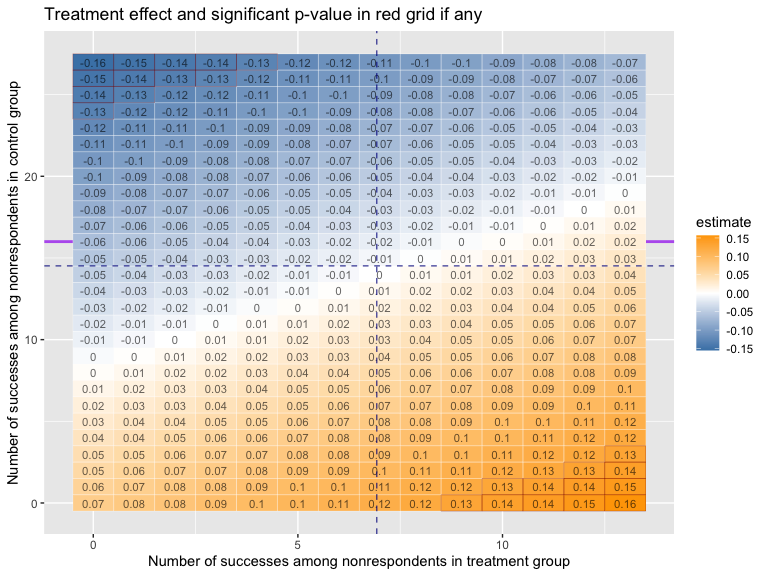

```r
# Using `both`
TippingPoint(outcome=tippingdata$binary,treat= tippingdata$treat,
             plot.type = "both",ind.values = TRUE,
             impValuesT  = NA,  impValuesC = NA,
             summary.type = "density", alpha = 0.95, S=1.5, n.grid = 100,
             HistMeanT = c(0.38,0.4), HistMeanC =  c(0.2,0.55))
```

```
##
## Group Information:
##
## Groups                       Treatment   Control
## Size                          150         120
## Number of nonrespondents      26          39
## % of nonrespondents           0.1733333   0.325
## Observed average response     127.6397    122.6907
## Observed min response         105.6767    73.54343
## Observed max response         152.8064    152.8064
```

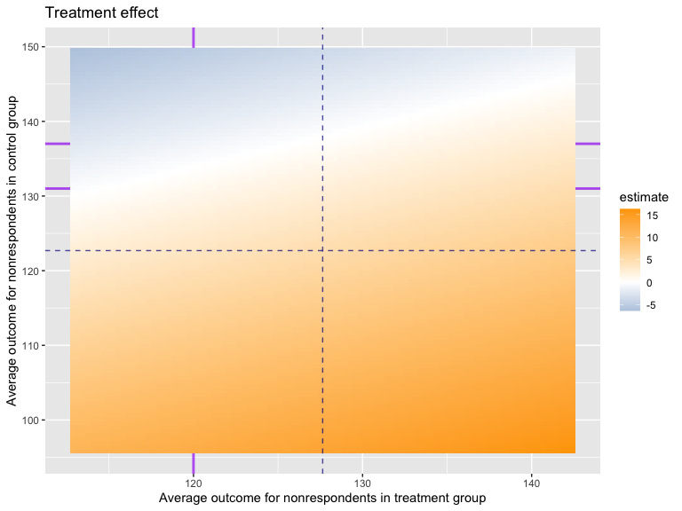

```r
# for continuous outcome
TippingPoint(continuous~treat, data=tippingdata,
             group.infor=TRUE, plot.type = "estimate",ind.values = TRUE,
             impValuesT  = NA,  impValuesC = NA,
             summary.type = "density", alpha = 0.95, S=1.5, n.grid = 100,
             HistMeanT = c(120), HistMeanC =  c(131,137))
```

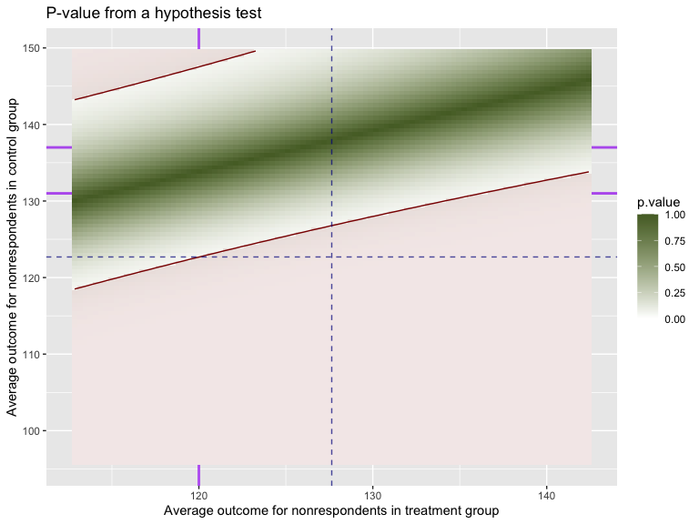

```r
TippingPoint(outcome=tippingdata$continuous,treat= tippingdata$treat,
             plot.type = "p.value",ind.values = TRUE,
             impValuesT  = NA,  impValuesC = NA,
             summary.type = "density", alpha = 0.95, S=1.5, n.grid = 100,
             HistMeanT = c(120), HistMeanC =  c(131,137))
```

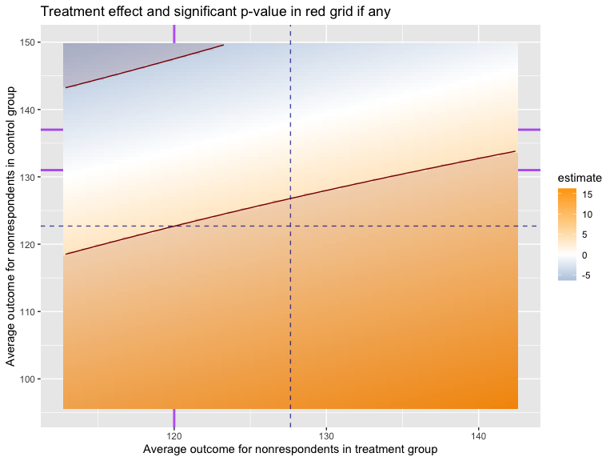

```r
TippingPoint(outcome=tippingdata$continuous,treat= tippingdata$treat,
             plot.type = "both",ind.values = TRUE,
             impValuesT  = NA,  impValuesC = NA,
             summary.type = "density", alpha = 0.95, S=1.5, n.grid = 100,
             HistMeanT = c(120), HistMeanC =  c(131,137))
```

## Using imputed data

```r
# Load the imputed dataset

data(imputedata)

# Show the first 6 rows of the data

head(imputedata)
```

```
##     MAR_T1   MAR_C1 MAR_T2 MAR_C2  MCAR_T1  MCAR_C1 MCAR_T2 MCAR_C2
## 1 118.1192 122.8743      7     14 128.4723 129.7369       6      13
## 2 129.7815 124.6130      5     19 130.1233 126.1398       6      11
## 3 124.3407 122.6200      5     17 124.9609 128.7701       5      14
## 4 126.6131 126.6311      4     15 126.9734 126.3991       4      10
## 5 127.8940 126.4212      8     16 125.9800 130.9947       5      10
## 6 122.1164 121.5700      4     13 127.0293 128.4050       5      13
```

```
##
## Group Information:
##
## Groups                       Treatment   Control
## Size                          150         120
## Number of nonrespondents      13          27
## % of nonrespondents           0.08666667      0.225
## Observed proportion           0.5328467   0.5376344
```

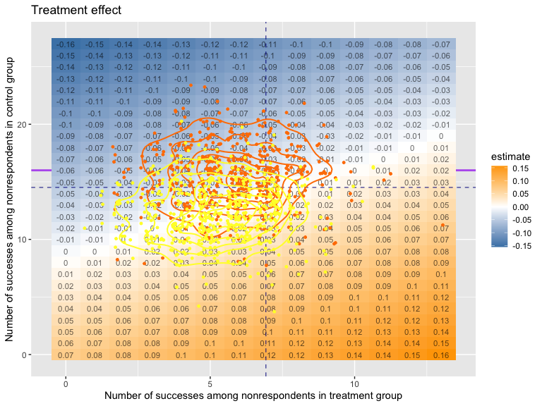

```r
## for binary outcome

TippingPoint(outcome=tippingdata$binary,
             treat= tippingdata$treat, group.infor=TRUE,
             plot.type = "estimate",ind.values = TRUE,
             impValuesT  = imputedata[,c("MAR_T2","MCAR_T2")],
             impValuesC = imputedata[,c("MAR_C2","MCAR_C2")],
             summary.type = "density", alpha = 0.95, S=1.5, n.grid = 100,
             HistMeanT = c(0.38,0.4), HistMeanC =  c(0.2,0.55))
```

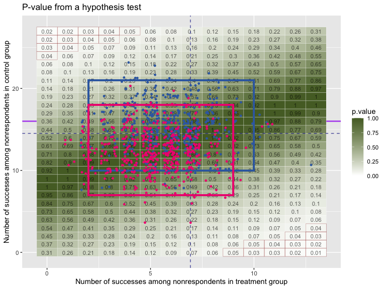

```r
# User-defined colors
TippingPoint(outcome=tippingdata$binary,treat= tippingdata$treat,
             plot.type = "p.value",ind.values = TRUE,
             impValuesT  = imputedata[,c("MAR_T2","MCAR_T2")],
             impValuesC = imputedata[,c("MAR_C2","MCAR_C2")],
             impValuesColor = RColorBrewer::brewer.pal(8,"Accent")[5:6],
             summary.type = "credible.region", alpha = 0.95, S=1.5, n.grid = 100,
             HistMeanT = c(0.38,0.4), HistMeanC =  c(0.2,0.55))
```

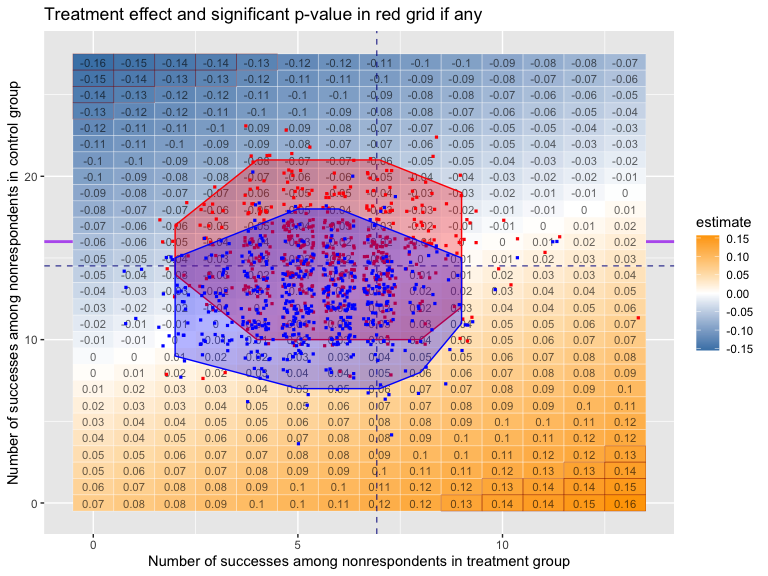

```r
# Using `point.size` and `point.shape` to control the points.
TippingPoint(outcome=tippingdata$binary,treat= tippingdata$treat,
             plot.type = "both",ind.values = TRUE,
             impValuesT  = imputedata[,c("MAR_T2","MCAR_T2")],
             impValuesC = imputedata[,c("MAR_C2","MCAR_C2")],
             impValuesColor =c("red","blue"),
             point.size=0.8,point.shape = 15,
             summary.type = "convex.hull", alpha = 0.95, S=1.5, n.grid = 100,
             HistMeanT = c(0.38,0.4), HistMeanC =  c(0.2,0.55))
```

```
##
## Group Information:
##
## Groups                       Treatment   Control
## Size                          150         120
## Number of nonrespondents      26          39
## % of nonrespondents           0.1733333   0.325
## Observed average response     127.6397    122.6907
## Observed min response         105.6767    73.54343
## Observed max response         152.8064    152.8064
```

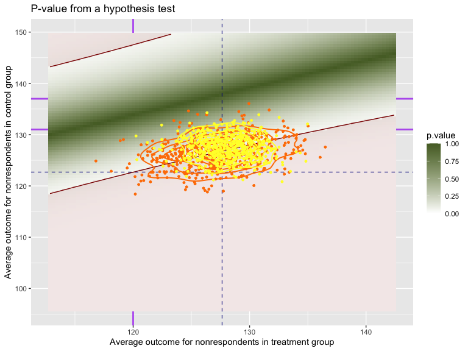

```r
## for continuous outcome
TippingPoint(outcome=tippingdata$continuous,
             treat= tippingdata$treat, group.infor=TRUE,
             plot.type = "p.value",ind.values = TRUE,
             impValuesT  = imputedata[,c("MAR_T1","MCAR_T1")],
             impValuesC = imputedata[,c("MAR_C1","MCAR_C1")],
             summary.type = "density", alpha = 0.95, S=1.5, n.grid = 100,
             HistMeanT = c(120), HistMeanC =  c(131,137))
```

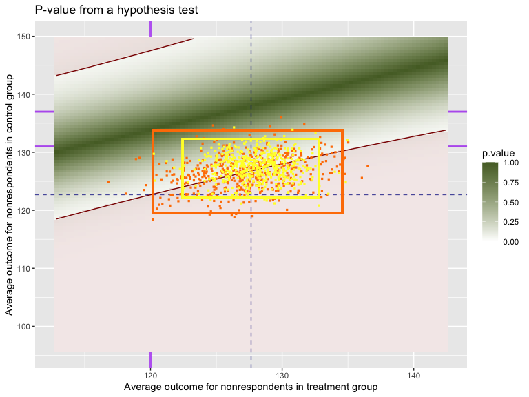

```r
# Using `point.size` and `point.shape` to control the points.
TippingPoint(outcome=tippingdata$continuous,treat= tippingdata$treat,
             plot.type = "p.value",ind.values = TRUE,
             impValuesT  = imputedata[,c("MAR_T1","MCAR_T1")],
             impValuesC = imputedata[,c("MAR_C1","MCAR_C1")],
             point.size = 0.8, point.shape = 15,
             summary.type = "credible.region", alpha = 0.95, S=1.5, n.grid = 100,
             HistMeanT = c(120), HistMeanC =  c(131,137))
```

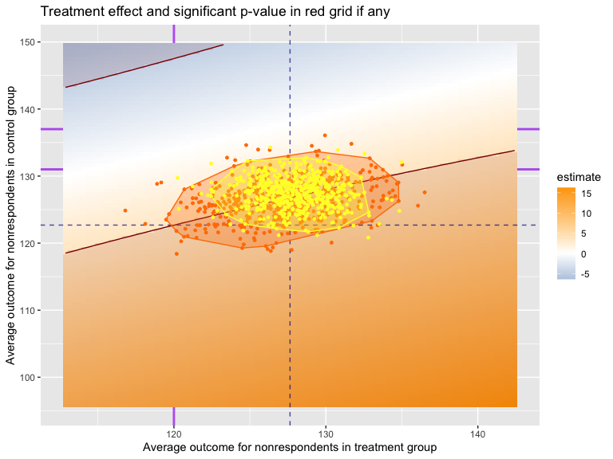

```r
TippingPoint(outcome=tippingdata$continuous,treat= tippingdata$treat,
             plot.type = "both",ind.values = TRUE,
             impValuesT  = imputedata[,c("MAR_T1","MCAR_T1")],
             impValuesC = imputedata[,c("MAR_C1","MCAR_C1")],
             summary.type = "convex.hull", alpha = 0.95, S=1.5, n.grid = 100,
             HistMeanT = c(120), HistMeanC =  c(131,137))
```

## Reference

The `TippingPoint` package is created based on Liublinska and Rubin’s work. For more details:

- Liublinska, V. and Rubin, D.B. Enhanced Tipping-Point Displays. In JSM Proceedings, Section on Survey Research Methods, San Diego, CA: American Statistical Association. 3861-3686 (2012).
- Liublinska, V. & Rubin, D.B. Sensitivity analysis for a partially missing binary outcome in a two-arm randomized clinical trial. Stat Med 33, 4170-85 (2014).
- Liublinska, V. (May, 2013) Sensitivity Analyses in Empirical Studies Plagued with Missing Data. PhD Dissertation, Harvard University, https://dash.harvard.edu/handle/1/11124841
- https://sites.google.com/site/vliublinska/research